# Modelled trait composition of 1970s avian bioregion clusters

WM

2026-05-05

## Aim

This notebook summarizes which kinds of species make up the 1970s modelled avian bioregion clusters. These are the Atlas 1 reference clusters from the avian bioregion PCA analysis, and the composition estimates use HMSC modelled species probabilities only.

For each 1970s cluster, predicted species probabilities are summed within thermal-affinity, migratory-strategy, and foraging-guild groups. These sums are then divided by the total expected richness among species with known values for that trait family. The reported percentages therefore describe the expected trait composition of the modelled 1970s community, not raw species counts.

## Load Model Outputs And Traits

## Modelled Cluster Composition

## Diagnostics

Thermal-affinity group sizes from STI quintiles.

| thermal_group | n_species |
| --- | --- |
| very cold | 32 |
| cold | 31 |
| medium | 31 |
| warm | 31 |
| very warm | 32 |

Checks that model prediction rows join to bioregion cluster assignments.

| atlas | n_prediction_sites | n_sites_without_cluster |
| --- | --- | --- |
| 1 | 1776 | 0 |

Modelled species with available trait metadata.

| trait_family | n_model_species | n_species_with_trait | n_species_missing_trait |
| --- | --- | --- | --- |
| Thermal affinity | 157 | 157 | 0 |
| Migratory strategy | 157 | 157 | 0 |
| Foraging guild | 157 | 157 | 0 |

Checks that trait percentages sum to 100 within each 1970s cluster-trait family.

| atlas | period | bioregion | trait_family | n_trait_groups | percent_sum | max_abs_deviation_from_100 | expected_total_richness_known_trait |
| --- | --- | --- | --- | --- | --- | --- | --- |
| 1 | 1970s | Cluster 1 | Thermal affinity | 5 | 100 | 0 | 21445.77 |
| 1 | 1970s | Cluster 1 | Migratory strategy | 5 | 100 | 0 | 21445.77 |
| 1 | 1970s | Cluster 1 | Foraging guild | 34 | 100 | 0 | 21445.77 |
| 1 | 1970s | Cluster 2 | Thermal affinity | 5 | 100 | 0 | 51968.27 |
| 1 | 1970s | Cluster 2 | Migratory strategy | 5 | 100 | 0 | 51968.27 |
| 1 | 1970s | Cluster 2 | Foraging guild | 34 | 100 | 0 | 51968.27 |
| 1 | 1970s | Cluster 3 | Thermal affinity | 5 | 100 | 0 | 21994.07 |
| 1 | 1970s | Cluster 3 | Migratory strategy | 5 | 100 | 0 | 21994.07 |
| 1 | 1970s | Cluster 3 | Foraging guild | 34 | 100 | 0 | 21994.07 |

## Dominant Trait Groups

Dominant model-weighted trait group within each 1970s cluster.

| bioregion | trait_family | dominant_trait_group | percent | n_species | n_sites |
| --- | --- | --- | --- | --- | --- |
| Cluster 1 | Thermal affinity | medium | 27.7% | 31 | 401 |
| Cluster 1 | Migratory strategy | long-distance | 27.7% | 44 | 401 |
| Cluster 1 | Foraging guild | Foliage gleaners | 11.5% | 9 | 401 |
| Cluster 2 | Thermal affinity | medium | 29.9% | 31 | 879 |
| Cluster 2 | Migratory strategy | sedentary | 30.0% | 35 | 879 |
| Cluster 2 | Foraging guild | Foliage gleaners | 13.5% | 9 | 879 |
| Cluster 3 | Thermal affinity | medium | 31.9% | 31 | 496 |
| Cluster 3 | Migratory strategy | sedentary | 32.2% | 35 | 496 |
| Cluster 3 | Foraging guild | Foliage gleaners | 14.8% | 9 | 496 |

## Thermal And Migratory Composition

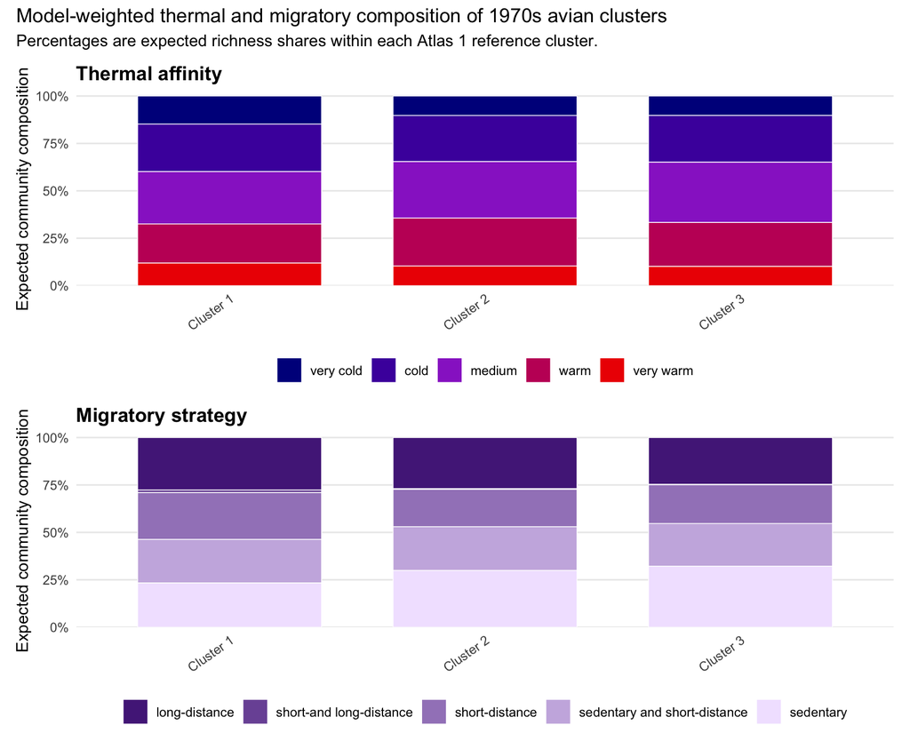

## Foraging Guild Composition

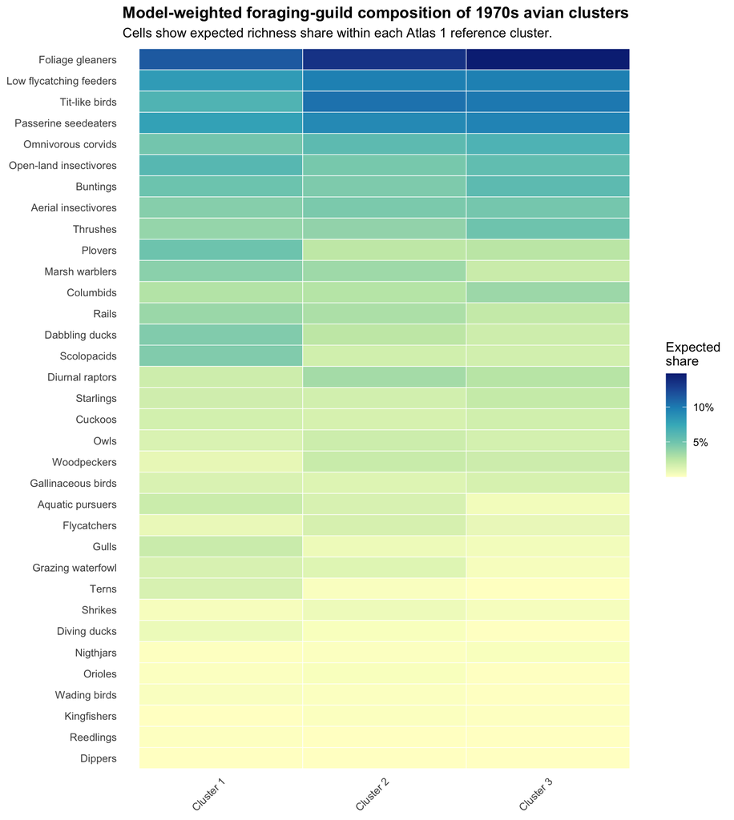

## Atlas 1 Environmental Profiles

This section compares the environmental context of the three Atlas 1 reference clusters. Values are centred on the national Atlas 1 median for each predictor and scaled by the national Atlas 1 standard deviation, so positive values mean that a cluster is above the national median for that variable and negative values mean that it is below the national median.

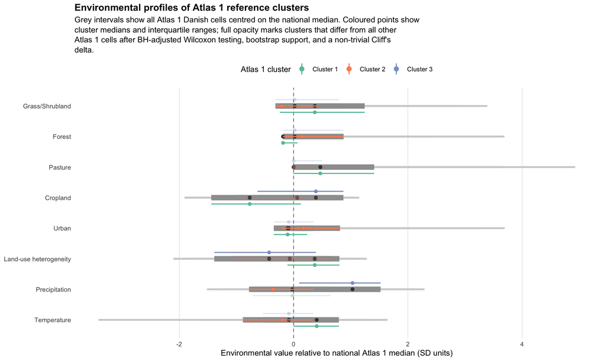

Atlas 1 environmental predictors where a cluster differs from all other Atlas 1 cells.

| bioregion | variable_label | n_cluster | n_other_cells | median_difference_cluster_minus_other | median_difference_ci_low | median_difference_ci_high | p_cluster_vs_other_adj | cliffs_delta_cluster_vs_other |
| --- | --- | --- | --- | --- | --- | --- | --- | --- |
| Cluster 1 | Land-use heterogeneity | 401 | 1375 | 0.576 | 0.445 | 0.707 | 0e+00 | 0.300 |
| Cluster 1 | Cropland | 401 | 1375 | -0.960 | -1.135 | -0.758 | 0e+00 | -0.336 |
| Cluster 1 | Forest | 401 | 1375 | -0.300 | -0.353 | -0.263 | 0e+00 | -0.349 |
| Cluster 1 | Grass/Shrubland | 401 | 1375 | 0.481 | 0.354 | 0.704 | 0e+00 | 0.257 |
| Cluster 1 | Pasture | 401 | 1375 | 0.468 | 0.349 | 0.561 | 0e+00 | 0.356 |
| Cluster 1 | Urban | 401 | 1375 | -0.150 | -0.240 | -0.064 | 5e-07 | -0.167 |
| Cluster 1 | Temperature | 401 | 1375 | 0.559 | 0.486 | 0.646 | 0e+00 | 0.437 |
| Cluster 2 | Forest | 879 | 897 | 0.280 | 0.203 | 0.356 | 0e+00 | 0.207 |
| Cluster 2 | Grass/Shrubland | 879 | 897 | -0.394 | -0.539 | -0.281 | 0e+00 | -0.213 |
| Cluster 2 | Urban | 879 | 897 | 0.266 | 0.184 | 0.340 | 0e+00 | 0.229 |
| Cluster 2 | Precipitation | 879 | 897 | -0.874 | -0.968 | -0.749 | 0e+00 | -0.334 |
| Cluster 2 | Temperature | 879 | 897 | -0.340 | -0.442 | -0.265 | 0e+00 | -0.260 |
| Cluster 3 | Land-use heterogeneity | 496 | 1280 | -0.526 | -0.723 | -0.345 | 0e+00 | -0.212 |
| Cluster 3 | Cropland | 496 | 1280 | 0.588 | 0.438 | 0.735 | 0e+00 | 0.224 |
| Cluster 3 | Precipitation | 496 | 1280 | 1.324 | 1.160 | 1.417 | 0e+00 | 0.524 |

## Drivers Of Shifts Into Cluster 2

This section asks what changed in the sites that were part of `Cluster 1` or `Cluster 3` in the 1970s, but were assigned to `Cluster 2` in a later atlas period. The analysis is paired by grid cell: for each focal site and species, the 1970s predicted probability is subtracted from the later predicted probability. Positive values indicate modelled increases, while negative values indicate modelled losses.

Trait-driver plots are shown as a size-normalized version. For each trait group, the summed expected-richness delta is divided by the number of modelled species in that group. This asks whether the average species in a trait group increased or decreased, rather than giving larger trait groups more weight simply because they contain more species.

Focal sites that shifted from Cluster 1 or Cluster 3 into Cluster 2.

| comparison | transition | n_sites | n_low_confidence | pct_low_confidence | median_assignment_margin |
| --- | --- | --- | --- | --- | --- |
| 1990s minus 1970s | Cluster 1 to Cluster 2 | 142 | 23 | 16.2% | 0.028 |
| 1990s minus 1970s | Cluster 3 to Cluster 2 | 219 | 35 | 16.0% | 0.031 |
| 2010s minus 1970s | Cluster 1 to Cluster 2 | 245 | 43 | 17.6% | 0.035 |
| 2010s minus 1970s | Cluster 3 to Cluster 2 | 392 | 41 | 10.5% | 0.038 |

Strongest size-normalized trait-group losses and gains among sites shifting into Cluster 2 by the 2010s.

| comparison | transition | trait_family | driver_direction_per_species | trait_value | n_species_in_trait_group | mean_expected_richness_delta | mean_expected_richness_delta_per_species | mean_expected_richness_loss_per_species | mean_expected_richness_gain_per_species | absolute_change_share_per_species | prop_sites_increase |
| --- | --- | --- | --- | --- | --- | --- | --- | --- | --- | --- | --- |
| 2010s minus 1970s | Cluster 1 to Cluster 2 | Foraging guild | Loss | Scolopacids | 9 | -0.983 | -0.1092 | -0.1221 | 0.0129 | 3.8% | 10% |
| 2010s minus 1970s | Cluster 1 to Cluster 2 | Foraging guild | Loss | Terns | 5 | -0.315 | -0.0630 | -0.0702 | 0.0072 | 2.2% | 17% |
| 2010s minus 1970s | Cluster 1 to Cluster 2 | Foraging guild | Loss | Dabbling ducks | 7 | -0.419 | -0.0599 | -0.0976 | 0.0377 | 2.1% | 34% |
| 2010s minus 1970s | Cluster 1 to Cluster 2 | Foraging guild | Loss | Buntings | 3 | -0.161 | -0.0536 | -0.0851 | 0.0315 | 1.9% | 33% |
| 2010s minus 1970s | Cluster 1 to Cluster 2 | Foraging guild | Loss | Orioles | 1 | -0.053 | -0.0525 | -0.0535 | 0.0010 | 1.8% | 16% |
| 2010s minus 1970s | Cluster 3 to Cluster 2 | Foraging guild | Loss | Orioles | 1 | -0.012 | -0.0120 | -0.0126 | 0.0006 | 0.4% | 14% |
| 2010s minus 1970s | Cluster 3 to Cluster 2 | Foraging guild | Loss | Scolopacids | 9 | -0.066 | -0.0073 | -0.0310 | 0.0237 | 0.2% | 44% |
| 2010s minus 1970s | Cluster 3 to Cluster 2 | Foraging guild | Loss | Gulls | 5 | -0.025 | -0.0051 | -0.0284 | 0.0234 | 0.2% | 34% |
| 2010s minus 1970s | Cluster 3 to Cluster 2 | Foraging guild | Loss | Starlings | 1 | -0.005 | -0.0046 | -0.0303 | 0.0257 | 0.1% | 46% |
| 2010s minus 1970s | Cluster 1 to Cluster 2 | Thermal affinity | Gain | warm | 31 | 4.016 | 0.1295 | -0.0369 | 0.1664 | 36.8% | 89% |
| 2010s minus 1970s | Cluster 1 to Cluster 2 | Thermal affinity | Gain | medium | 31 | 3.536 | 0.1141 | -0.0378 | 0.1519 | 32.4% | 84% |
| 2010s minus 1970s | Cluster 1 to Cluster 2 | Thermal affinity | Gain | very warm | 32 | 1.863 | 0.0582 | -0.0390 | 0.0972 | 16.5% | 82% |
| 2010s minus 1970s | Cluster 1 to Cluster 2 | Thermal affinity | Gain | cold | 31 | 1.325 | 0.0427 | -0.0723 | 0.1151 | 12.1% | 64% |
| 2010s minus 1970s | Cluster 1 to Cluster 2 | Thermal affinity | Gain | very cold | 32 | 0.238 | 0.0074 | -0.0651 | 0.0725 | 2.1% | 56% |
| 2010s minus 1970s | Cluster 1 to Cluster 2 | Migratory strategy | Gain | sedentary | 35 | 4.737 | 0.1354 | -0.0328 | 0.1681 | 35.3% | 88% |
| 2010s minus 1970s | Cluster 1 to Cluster 2 | Migratory strategy | Gain | sedentary and short-distance | 31 | 3.278 | 0.1057 | -0.0321 | 0.1379 | 27.5% | 85% |
| 2010s minus 1970s | Cluster 1 to Cluster 2 | Migratory strategy | Gain | short-and long-distance | 8 | 0.701 | 0.0876 | -0.0266 | 0.1142 | 22.8% | 95% |
| 2010s minus 1970s | Cluster 1 to Cluster 2 | Migratory strategy | Gain | short-distance | 39 | 1.300 | 0.0333 | -0.0699 | 0.1032 | 8.7% | 66% |
| 2010s minus 1970s | Cluster 1 to Cluster 2 | Migratory strategy | Gain | long-distance | 44 | 0.961 | 0.0218 | -0.0638 | 0.0856 | 5.7% | 61% |
| 2010s minus 1970s | Cluster 1 to Cluster 2 | Foraging guild | Gain | Grazing waterfowl | 2 | 0.445 | 0.2226 | -0.0494 | 0.2721 | 7.8% | 85% |
| 2010s minus 1970s | Cluster 1 to Cluster 2 | Foraging guild | Gain | Tit-like birds | 12 | 2.460 | 0.2050 | -0.0114 | 0.2164 | 7.2% | 93% |
| 2010s minus 1970s | Cluster 1 to Cluster 2 | Foraging guild | Gain | Diurnal raptors | 7 | 1.361 | 0.1945 | -0.0156 | 0.2101 | 6.8% | 93% |
| 2010s minus 1970s | Cluster 1 to Cluster 2 | Foraging guild | Gain | Omnivorous corvids | 7 | 1.233 | 0.1761 | -0.0318 | 0.2079 | 6.2% | 86% |
| 2010s minus 1970s | Cluster 1 to Cluster 2 | Foraging guild | Gain | Foliage gleaners | 9 | 1.510 | 0.1678 | -0.0156 | 0.1835 | 5.9% | 91% |
| 2010s minus 1970s | Cluster 3 to Cluster 2 | Thermal affinity | Gain | warm | 31 | 4.827 | 0.1557 | -0.0198 | 0.1755 | 28.3% | 97% |
| 2010s minus 1970s | Cluster 3 to Cluster 2 | Thermal affinity | Gain | medium | 31 | 4.532 | 0.1462 | -0.0171 | 0.1633 | 26.6% | 97% |
| 2010s minus 1970s | Cluster 3 to Cluster 2 | Thermal affinity | Gain | cold | 31 | 3.396 | 0.1096 | -0.0327 | 0.1423 | 19.9% | 90% |
| 2010s minus 1970s | Cluster 3 to Cluster 2 | Thermal affinity | Gain | very warm | 32 | 2.525 | 0.0789 | -0.0174 | 0.0963 | 14.3% | 96% |
| 2010s minus 1970s | Cluster 3 to Cluster 2 | Thermal affinity | Gain | very cold | 32 | 1.912 | 0.0597 | -0.0167 | 0.0764 | 10.9% | 90% |
| 2010s minus 1970s | Cluster 3 to Cluster 2 | Migratory strategy | Gain | sedentary | 35 | 5.206 | 0.1487 | -0.0233 | 0.1720 | 27.2% | 95% |
| 2010s minus 1970s | Cluster 3 to Cluster 2 | Migratory strategy | Gain | sedentary and short-distance | 31 | 3.949 | 0.1274 | -0.0174 | 0.1448 | 23.3% | 93% |
| 2010s minus 1970s | Cluster 3 to Cluster 2 | Migratory strategy | Gain | short-and long-distance | 8 | 0.768 | 0.0960 | -0.0015 | 0.0974 | 17.5% | 100% |
| 2010s minus 1970s | Cluster 3 to Cluster 2 | Migratory strategy | Gain | short-distance | 39 | 3.598 | 0.0922 | -0.0220 | 0.1142 | 16.8% | 95% |
| 2010s minus 1970s | Cluster 3 to Cluster 2 | Migratory strategy | Gain | long-distance | 44 | 3.671 | 0.0834 | -0.0233 | 0.1067 | 15.2% | 89% |
| 2010s minus 1970s | Cluster 3 to Cluster 2 | Foraging guild | Gain | Grazing waterfowl | 2 | 0.549 | 0.2747 | -0.0052 | 0.2798 | 8.3% | 95% |
| 2010s minus 1970s | Cluster 3 to Cluster 2 | Foraging guild | Gain | Passerine seedeaters | 12 | 2.410 | 0.2008 | -0.0140 | 0.2149 | 6.1% | 99% |
| 2010s minus 1970s | Cluster 3 to Cluster 2 | Foraging guild | Gain | Tit-like birds | 12 | 2.303 | 0.1919 | -0.0104 | 0.2023 | 5.8% | 95% |
| 2010s minus 1970s | Cluster 3 to Cluster 2 | Foraging guild | Gain | Omnivorous corvids | 7 | 1.301 | 0.1859 | -0.0211 | 0.2070 | 5.6% | 94% |
| 2010s minus 1970s | Cluster 3 to Cluster 2 | Foraging guild | Gain | Low flycatching feeders | 9 | 1.627 | 0.1808 | -0.0296 | 0.2104 | 5.5% | 97% |

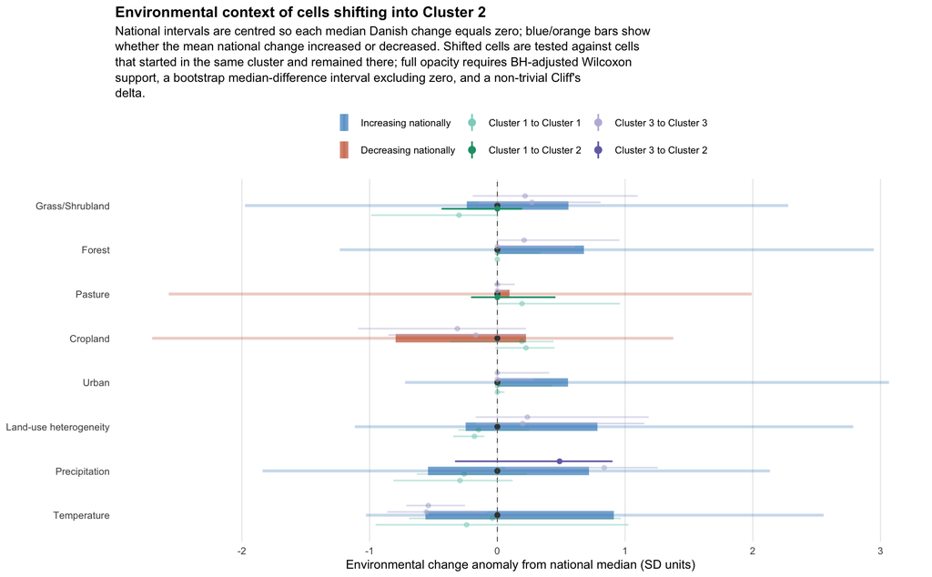

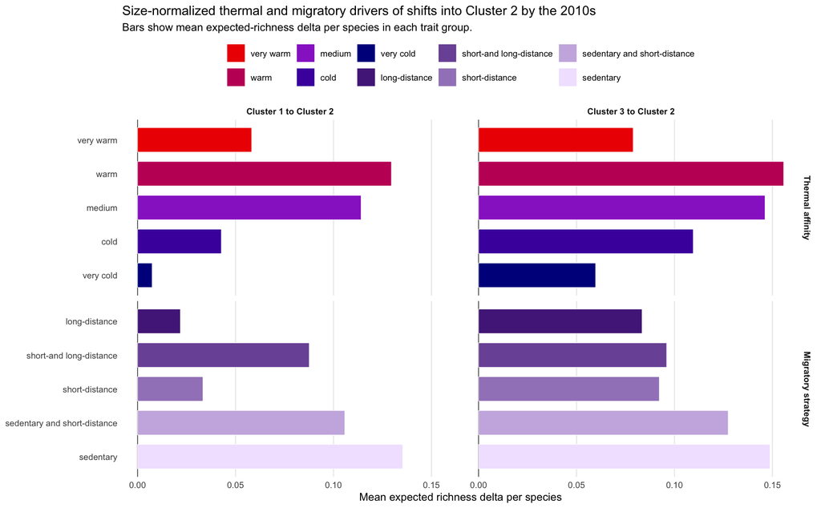

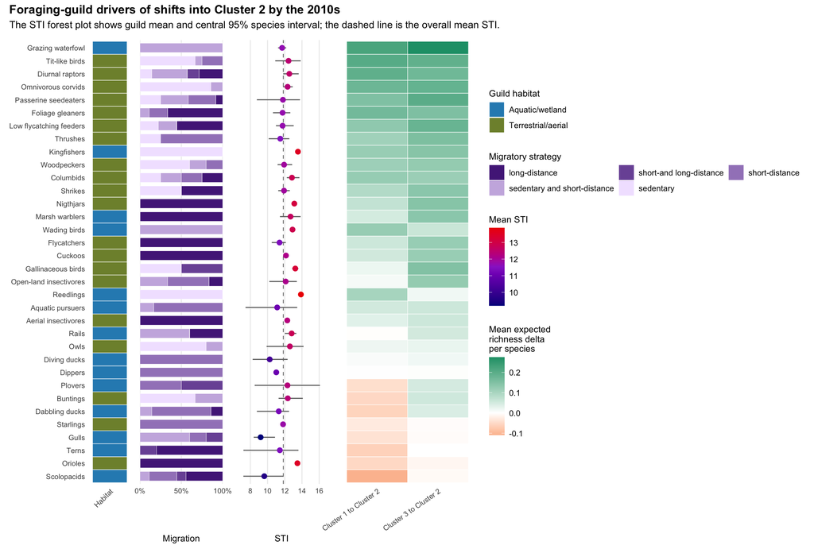